# Homework 4

```r
library(ggplot2)
load("../data/RainData.RData")      # gives `dati` (stations, all years) and `grid` (prediction points)

# Coordinates in km, centred on the stations (better numerical behaviour); altitude in km.
# The same centring is used for the stations and for the grid.
x0 <- mean(dati$XUTM); y0 <- mean(dati$YUTM)
prep <- function(d) transform(d, x = (XUTM - x0) / 1000, y = (YUTM - y0) / 1000, alt = Quota / 1000)
dati <- prep(dati[!is.na(dati$totanno), ])
grid <- prep(grid)
stopifnot(!anyNA(dati[, c("x", "y", "alt")]), !anyNA(grid[, c("x", "y", "alt")]))

# One list per year: data, response, coordinates and matrix of distances between stations
yrs <- lapply(split(dati, dati$anno), function(d)
  list(data = d, z = d$totanno, co = as.matrix(d[, c("x", "y")]),
       D = as.matrix(dist(d[, c("x", "y")]))))
years <- names(yrs)
years <- c("1973", "1974", "1980")
yrs <- yrs[years]
```

This study focuses on annual rainfall data (`totanno`, in mm), especially on the measurements during years 1973, 1974 and 1980. For each year $t$ the model used is the one studied in class:

$$Z_t(s) = X(s)\beta_t + W_t(s) + \varepsilon_t(s)$$

where $X(s)\beta_t$ is a trend (constant, coordinates and/or altitude), $W_t(s)$ a Gaussian process with partial sill $\sigma^2_t$ and range $\phi_t$, and $\varepsilon_t(s)$ the nugget, with variance $\tau^2_t$. The parameters are estimated by maximum likelihood (ML), **year by year**.

The steps are:

1. fit by ML every combination of trend and covariance model, in every year, and check the convergence of each fit;
2. compare the combinations by leave-one-out cross-validation, model are selected separately for each year using CRPS as a selection criterion;
3. keep **the best model independently for each year** and use it, after a log transformation of the rainfall (Section 1.6), to krige on `grid`.

The number of stations per year is:

```r
knitr::kable(data.frame(Year = years,
                        Stations = sapply(yrs, function(y) length(y$z)),
                        `Duplicated coordinates` = sapply(yrs, function(y) sum(duplicated(y$co))),
                        check.names = FALSE), row.names = FALSE)
```

| Year | Stations | Duplicated coordinates |
| --- | --- | --- |
| 1973 | 188 | 0 |
| 1974 | 187 | 0 |
| 1980 | 178 | 0 |

# AI prompts

As in the previous homeworks, we gave the AI the data, the method we wanted and the checks to do.

> I’m a student in spatial statistics. I have a dataset in R from RainData.RData which contains yearly total rainfall (totanno) at various weather stations across several years, along with their UTM coordinates and altitude (Quota). First, I need to filter the data to work specifically on three years: 1973, 1974, and 1980. For each of these three years independently, I need to: 1) Choose a trend and a variogram model, and justify my choice using Proper scores. 2) Interpolate the rainfall on the estimation grid using kriging in a maximum likelihood framework. 3) Build pointwise prediction intervals on the grid. 4) Map the results (including the prediction intervals), comment on the output, and compare the spatial dynamics across the three years. To do this, please write R code to loop over the three selected years. Inside the loop, first compare different trends (e.g., constant, linear in coordinates, and including altitude as a covariate) and different covariance models (exponential, spherical, gaussian, matern with a few kappa) fitted by ML with a nugget. To justify the choice of the best trend and covariance combination for each year, do not use AIC; instead, compute Proper scores (like CRPS and LogS) via leave-one-out cross-validation. Once the best model is selected for a year, do universal kriging on the grid. Calculate the predictions and the 95% pointwise prediction intervals (make sure to include the nugget variance so the interval is valid for a new observation). Map the predictions and the upper/lower confidence bounds. Give the R code in chunks for an RMarkdown document. Explain each result and the spatial maps simply, without over-interpreting, and make sure to include a final comparison between 1973, 1974, and 1980.

**Answer.** Here is the analysis asked for by these prompt.

# Part 1: choice of the model

## 1.1 Candidate models

```r
# Trends: written as formulas in x, y (coordinates, km) and alt (altitude, km).
# Add other trends here, for example: quadratic = ~ x + y + I(x^2) + I(x * y) + I(y^2)
trends <- list(constant        = ~ 1,
               linear          = ~ x + y,
               altitude        = ~ alt,
               linear_altitude = ~ x + y + alt)

# Covariance models (kappa is the smoothness of the Matern model)
covs <- data.frame(label = c("Exponential", "Spherical", "Gaussian", "Matern 1.5", "Matern 2.5"),
                   model = c("exponential", "spherical", "gaussian", "matern", "matern"),
                   kappa = c(0.5, 0.5, 0.5, 1.5, 2.5))

# Starting values of the optimiser: range = 0.1, 0.3 and 1 times half the largest distance,
# combined with nu = tau2 / sigma2 = 0.1 and 1  ->  6 starting values for every fit
start_grid <- expand.grid(phi = c(0.1, 0.3, 1), nu = c(0.1, 1))
```

```r
# Table of all the models: every trend combined with every covariance model
mod <- expand.grid(j = seq_len(nrow(covs)), tr = names(trends), stringsAsFactors = FALSE)
all_models <- data.frame(Model           = seq_len(nrow(mod)),
                         Trend           = mod$tr,
                         `Trend formula` = unname(sapply(trends[mod$tr], deparse)),
                         Covariance      = covs$label[mod$j],
                         Kappa           = covs$kappa[mod$j],
                         check.names = FALSE)
knitr::kable(all_models, row.names = FALSE, caption = "Candidate models")
```

Candidate models

| Model | Trend | Trend formula | Covariance | Kappa |
| --- | --- | --- | --- | --- |
| 1 | constant | ~1 | Exponential | 0.5 |
| 2 | constant | ~1 | Spherical | 0.5 |
| 3 | constant | ~1 | Gaussian | 0.5 |
| 4 | constant | ~1 | Matern 1.5 | 1.5 |
| 5 | constant | ~1 | Matern 2.5 | 2.5 |
| 6 | linear | ~x + y | Exponential | 0.5 |
| 7 | linear | ~x + y | Spherical | 0.5 |
| 8 | linear | ~x + y | Gaussian | 0.5 |
| 9 | linear | ~x + y | Matern 1.5 | 1.5 |
| 10 | linear | ~x + y | Matern 2.5 | 2.5 |
| 11 | altitude | ~alt | Exponential | 0.5 |
| 12 | altitude | ~alt | Spherical | 0.5 |
| 13 | altitude | ~alt | Gaussian | 0.5 |
| 14 | altitude | ~alt | Matern 1.5 | 1.5 |
| 15 | altitude | ~alt | Matern 2.5 | 2.5 |
| 16 | linear_altitude | ~x + y + alt | Exponential | 0.5 |
| 17 | linear_altitude | ~x + y + alt | Spherical | 0.5 |
| 18 | linear_altitude | ~x + y + alt | Gaussian | 0.5 |
| 19 | linear_altitude | ~x + y + alt | Matern 1.5 | 1.5 |
| 20 | linear_altitude | ~x + y + alt | Matern 2.5 | 2.5 |

There are 4 trends and 5 covariance models, so 20 models per year.

## 1.2 Functions

```r
# ---- correlation functions (same parametrisation as geoR) ----
corr_fun <- function(h, model, phi, kappa) {
  u <- h / phi
  switch(model,
    exponential = exp(-u),
    spherical   = ifelse(u < 1, 1 - 1.5 * u + 0.5 * u^3, 0),
    gaussian    = exp(-u^2),
    matern      = { r <- u^kappa * besselK(u, kappa) / (2^(kappa - 1) * gamma(kappa))
                    r[u == 0] <- 1
                    r })
}

# distances between two sets of points (rows of a and rows of b)
cross_dist <- function(a, b)
  sqrt(outer(a[, 1], b[, 1], "-")^2 + outer(a[, 2], b[, 2], "-")^2)

# ---- ML for given phi and nu = tau2 / sigma2 ----
# The trend coefficients and sigma2 have a closed form (generalised least squares),
# so only phi and nu have to be searched numerically.
gls_ml <- function(phi, nu, z, X, D, model, kappa) {
  n  <- length(z)
  R  <- chol(corr_fun(D, model, phi, kappa) + diag(nu, n))
  Xs <- backsolve(R, X, transpose = TRUE)          # X and z "decorrelated"
  zs <- backsolve(R, z, transpose = TRUE)
  beta <- solve(crossprod(Xs), crossprod(Xs, zs))
  s2   <- sum((zs - Xs %*% beta)^2) / n
  ll   <- -0.5 * (n * log(2 * pi) + 2 * sum(log(diag(R))) + n * log(s2) + n)
  list(logLik = ll, beta = c(beta), sigma2 = s2)
}

# ---- ML fit from the 6 starting values; convergence is checked for each one ----
fit_ml <- function(z, X, D, model, kappa) {
  maxd   <- max(D)
  lower  <- log(c(0.005 * maxd, 1e-4))             # bounds of log(phi) and log(nu)
  upper  <- log(c(5 * maxd, 100))
  nll <- function(p) {                             # minus the log-likelihood
    v <- tryCatch(-gls_ml(exp(p[1]), exp(p[2]), z, X, D, model, kappa)$logLik,
                  error = function(e) 1e10)
    if (is.finite(v)) v else 1e10
  }
  runs <- do.call(rbind, lapply(seq_len(nrow(start_grid)), function(k) {
    start <- log(c(start_grid$phi[k] * maxd / 2, start_grid$nu[k]))
    o <- optim(start, nll, method = "L-BFGS-B", lower = lower, upper = upper)
    data.frame(converged = (o$convergence == 0), logLik = -o$value,
               phi = exp(o$par[1]), nu = exp(o$par[2]))
  }))
  ok <- runs$converged
  if (!any(ok)) ok <- rep(TRUE, nrow(runs))        # no start converged (n_conv = 0 will show it)
  best <- runs[ok, ][which.max(runs$logLik[ok]), ] # best likelihood among the converged runs
  g <- gls_ml(best$phi, best$nu, z, X, D, model, kappa)
  list(model = model, kappa = kappa, phi = best$phi, sigma2 = g$sigma2,
       tau2 = best$nu * g$sigma2, logLik = g$logLik,
       n_conv = sum(runs$converged),               # number of converged starting values
       spread = if (sum(runs$converged) > 1)       # logLik difference between converged runs
                  diff(range(runs$logLik[runs$converged])) else NA)
}

# ---- universal kriging ----
# S: covariance of the observations (with nugget), C: covariance between the observations
# and the points to predict (latent process), X0: trend matrix at the points to predict.
# The parameters p are treated as known. Two variances are returned:
#  - var_latent: latent process S(s0) = X(s0) beta + W(s0)  (no nugget)
#  - var_obs   : new observation Z(s0) = S(s0) + eps(s0)    (latent variance + tau2)
krige_uk <- function(z, X, S, C, X0, p) {
  Si  <- solve(S)
  A   <- solve(t(X) %*% Si %*% X)
  b   <- A %*% t(X) %*% Si %*% z                   # GLS trend coefficients
  SiC <- Si %*% C
  R   <- X0 - t(SiC) %*% X
  v_latent <- p$sigma2 - colSums(C * SiC) + rowSums((R %*% A) * R)
  v_latent <- pmax(v_latent, 0)                    # avoids tiny negative values (rounding)
  data.frame(pred = c(X0 %*% b + t(SiC) %*% (z - X %*% b)),
             var_latent = v_latent, var_obs = v_latent + p$tau2)
}

# ---- leave-one-out: each station is removed and predicted from the others (p fixed) ----
loo <- function(z, X, D, p) {
  C <- p$sigma2 * corr_fun(D, p$model, p$phi, p$kappa)   # latent covariance between stations
  S <- C + diag(p$tau2, length(z))                       # covariance of the observations
  do.call(rbind, lapply(seq_along(z), function(i)
    krige_uk(z[-i], X[-i, , drop = FALSE], S[-i, -i], C[-i, i, drop = FALSE],
             X[i, , drop = FALSE], p)))
}

# ---- kriging at the points of a grid g ----
krige_grid <- function(z, X, co, p, g, trend) {
  C <- p$sigma2 * corr_fun(cross_dist(co, as.matrix(g[, c("x", "y")])), p$model, p$phi, p$kappa)
  S <- p$sigma2 * corr_fun(as.matrix(dist(co)), p$model, p$phi, p$kappa) + diag(p$tau2, length(z))
  krige_uk(z, X, S, C, model.matrix(trend, g), p)
}

# ---- CRPS of a Gaussian predictive distribution (smaller is better) ----
crps_norm <- function(y, m, s) {
  u <- (y - m) / s
  s * (u * (2 * pnorm(u) - 1) + 2 * dnorm(u) - 1 / sqrt(pi))
}

# ---- LogS of a Gaussian predictive distribution (smaller is better) ----
logs_norm <- function(y, m, s) {
  0.5 * log(2 * pi * s^2) + 0.5 * ((y - m) / s)^2
}

# ---- CRPS of a log-normal predictive distribution: log(Y) ~ N(m, s^2), y in the original scale ----
crps_lnorm <- function(y, m, s) {
  w <- (log(y) - m) / s
  y * (2 * pnorm(w) - 1) - 2 * exp(m + s^2 / 2) * (pnorm(w - s) + pnorm(s / sqrt(2)) - 1)
}
```

The kriging is a universal kriging with the formulas of the course, where the parameters are the ML estimates (plug-in). The predictor is the same for the latent process and for a new observation, only the variance changes: the variance of a new observation is the variance of the latent process plus $\tau^2$.

## 1.3 Fit and cross-validation of all the models

For every year, trend and covariance model, we (i) fit the model by ML from the 6 starting values on the full sample of stations, and (ii) predict each station from the remaining $n - 1$ stations via leave-one-out cross-validation (LOO-CV).

**Methodological note on plug-in cross-validation:** When predicting station $i$ from the remaining $n - 1$ stations in `loo()`, the trend coefficients $\hat{\beta}_{(-i)}$ are re-estimated by generalised least squares on the $n - 1$ training stations, whereas the covariance parameters $(\hat{\sigma}^2, \hat{\phi}, \hat{\tau}^2)$ are kept fixed at their full-sample ML estimates (to avoid refitting $20 \times 553 = 11,060$ numerical ML optimisations). Because the held-out station $i$ contributed to the estimation of the covariance parameters, the resulting LOO-CV scores (CRPS, LogS, RMSE) and empirical coverages are **conditional on plug-in covariance estimates** and therefore slightly optimistic compared to a fully refitted cross-validation.

Since the observed values at the stations include micro-scale variability and measurement noise (the nugget), the predictive distributions are evaluated using the variance of a **new observation** (`var_obs = var_latent + tau2`). The empirical coverage is the percentage of observed stations falling inside their 95% **prediction interval**.

```r
fits   <- list()                                   # one fit per year, trend and covariance
scores <- list()
for (yr in years) {
  y <- yrs[[yr]]
  for (tr in names(trends)) {
    X <- model.matrix(trends[[tr]], y$data)
    for (j in seq_len(nrow(covs))) {
      f  <- fit_ml(y$z, X, y$D, covs$model[j], covs$kappa[j])
      cv <- loo(y$z, X, y$D, f)
      e  <- y$z - cv$pred
      s  <- sqrt(cv$var_obs)
      fits[[paste(yr, tr, covs$label[j])]] <- f
      scores[[length(scores) + 1]] <- data.frame(
        year = yr, trend = tr, covariance = covs$label[j],
        n_conv = f$n_conv, spread = f$spread,
        CRPS = mean(crps_norm(y$z, cv$pred, s)), RMSE = sqrt(mean(e^2)),
        LogS = mean(logs_norm(y$z, cv$pred, s)),
        coverage = 100 * mean(abs(e / s) < 1.96))
    }
  }
}
scores <- do.call(rbind, scores)
```

## 1.4 Convergence of the ML fits

`n_conv` is the number of starting values (out of 6) for which the optimiser reports a successful convergence (code 0). Only the converged runs are used to choose the estimates, and `spread` is the difference of log-likelihood between the converged runs of the same fit: a large value means that different starting values reach different optima.

```r
knitr::kable(data.frame(
  `Fits (year x trend x covariance)`                 = nrow(scores),
  `Fits with no converged start`                     = sum(scores$n_conv == 0),
  `Fits with at least one start not converged`       = sum(scores$n_conv < nrow(start_grid)),
  `Fits where converged starts differ by more than 0.1` = sum(scores$spread > 0.1, na.rm = TRUE),
  check.names = FALSE), row.names = FALSE)
```

| Fits (year x trend x covariance) | Fits with no converged start | Fits with at least one start not converged | Fits where converged starts differ by more than 0.1 |
| --- | --- | --- | --- |
| 60 | 0 | 0 | 12 |

```r
problems <- scores[scores$n_conv < nrow(start_grid) | (scores$spread > 0.1) %in% TRUE,
                   c("year", "trend", "covariance", "n_conv", "spread")]
knitr::kable(head(problems, 30), digits = 2, row.names = FALSE,
             caption = "Fits with a convergence problem (first 30)")
```

Fits with a convergence problem (first 30)

| year | trend | covariance | n_conv | spread |
| --- | --- | --- | --- | --- |
| 1973 | constant | Spherical | 6 | 3.14 |
| 1973 | linear | Spherical | 6 | 3.48 |
| 1973 | altitude | Spherical | 6 | 0.47 |
| 1973 | linear_altitude | Spherical | 6 | 2.39 |
| 1974 | constant | Spherical | 6 | 3.22 |
| 1974 | linear | Spherical | 6 | 3.54 |
| 1974 | altitude | Spherical | 6 | 2.33 |
| 1974 | linear_altitude | Spherical | 6 | 1.91 |
| 1980 | constant | Spherical | 6 | 0.52 |
| 1980 | linear | Spherical | 6 | 1.01 |
| 1980 | altitude | Spherical | 6 | 2.18 |
| 1980 | linear_altitude | Spherical | 6 | 1.02 |

## 1.5 Comparison of the models

For each year, the models are ranked based on their leave-one-out scores. The best model for a given year is the one minimizing the CRPS and LogS.

```r
# Extract the best model (minimum CRPS) for EACH year
best_models <- do.call(rbind, lapply(split(scores, scores$year), function(sub) {
  sub[which.min(sub$CRPS), c("year", "trend", "covariance", "CRPS", "LogS", "RMSE", "coverage")]
}))
rownames(best_models) <- NULL

# Table 1: Display only the best models
cat(knitr::kable(best_models, digits = 2, row.names = FALSE,
                 caption = "Best model selected independently for each year (minimum CRPS)"),
    sep = "\n")
```

Best model selected independently for each year (minimum CRPS)

| year | trend | covariance | CRPS | LogS | RMSE | coverage |
| --- | --- | --- | --- | --- | --- | --- |
| 1973 | linear_altitude | Spherical | 149.26 | 7.02 | 266.84 | 95.74 |
| 1974 | altitude | Spherical | 127.39 | 6.89 | 234.29 | 94.65 |
| 1980 | altitude | Exponential | 170.72 | 7.21 | 322.79 | 92.70 |

```r
cat("\n\n")
```

```r
# Sort all tested models by year, and then by CRPS (from lowest/best to highest)
all_models_sorted <- scores[order(scores$year, scores$CRPS),
                            c("year", "trend", "covariance", "CRPS", "LogS", "RMSE", "coverage")]
rownames(all_models_sorted) <- NULL

# Table 2: the 5 best models of each year, one table per year
for (yr in years) {
  top5 <- head(all_models_sorted[all_models_sorted$year == yr, -1], 5)   # drop the year column
  cat(knitr::kable(top5, digits = 2, row.names = FALSE,
                   caption = paste0("Five best models in ", yr, " (sorted by CRPS)")),
      sep = "\n")
  cat("\n\n")
}
```

Five best models in 1973 (sorted by CRPS)

| trend | covariance | CRPS | LogS | RMSE | coverage |
| --- | --- | --- | --- | --- | --- |
| linear_altitude | Spherical | 149.26 | 7.02 | 266.84 | 95.74 |
| altitude | Exponential | 149.57 | 7.02 | 267.92 | 94.68 |
| altitude | Matern 1.5 | 149.85 | 7.02 | 268.44 | 94.68 |
| linear_altitude | Exponential | 149.97 | 7.03 | 268.41 | 94.68 |
| altitude | Matern 2.5 | 150.01 | 7.03 | 268.72 | 94.15 |

Five best models in 1974 (sorted by CRPS)

| trend | covariance | CRPS | LogS | RMSE | coverage |
| --- | --- | --- | --- | --- | --- |
| altitude | Spherical | 127.39 | 6.89 | 234.29 | 94.65 |
| altitude | Exponential | 128.04 | 6.90 | 235.45 | 94.12 |
| linear_altitude | Spherical | 128.09 | 6.89 | 235.40 | 94.65 |
| linear_altitude | Exponential | 128.55 | 6.90 | 236.12 | 94.12 |
| altitude | Matern 1.5 | 129.85 | 6.91 | 238.92 | 94.12 |

Five best models in 1980 (sorted by CRPS)

| trend | covariance | CRPS | LogS | RMSE | coverage |
| --- | --- | --- | --- | --- | --- |
| altitude | Exponential | 170.72 | 7.21 | 322.79 | 92.7 |
| linear_altitude | Exponential | 171.29 | 7.21 | 323.46 | 92.7 |
| altitude | Matern 1.5 | 171.59 | 7.22 | 324.97 | 92.7 |
| altitude | Spherical | 171.80 | 7.22 | 325.19 | 92.7 |
| altitude | Matern 2.5 | 172.00 | 7.22 | 325.88 | 92.7 |

```r
# Fonctions pour extraire dynamiquement le bon ajustement et la bonne tendance par année
fit_of <- function(yr) {
  best <- best_models[best_models$year == yr, ]
  fits[[paste(yr, best$trend, best$covariance)]]
}

trend_of <- function(yr) {
  best <- best_models[best_models$year == yr, ]
  trends[[best$trend]]
}
```

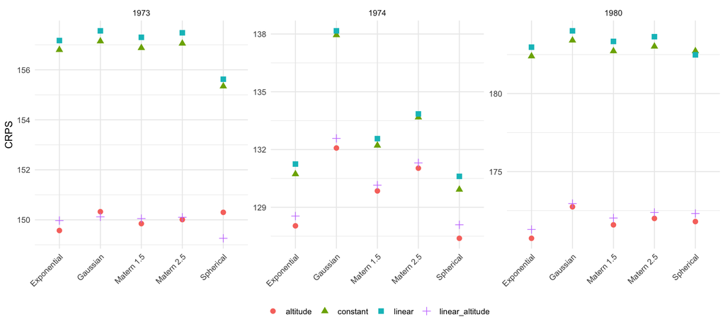

```r
# One panel per year, each with its own CRPS scale; no link between the years
ggplot(scores, aes(covariance, CRPS, colour = trend, shape = trend)) +
  geom_point(size = 2.5) + facet_wrap(~ year, nrow = 1, scales = "free_y") +
  labs(x = NULL, colour = NULL, shape = NULL) + theme_minimal() +
  theme(legend.position = "bottom", axis.text.x = element_text(angle = 45, hjust = 1))
```

*CRPS of every model, one panel per year (each panel has its own scale; smaller is better).*

Based on the results, the selection of the optimal model dynamically changes depending on the year. For 1973, the model combining spatial coordinates and topography (`linear_altitude`) with a Spherical covariance provides the best nominal performance, yielding a CRPS of 149.26 and a LogS of 7.02. However, it is important to note that for 1973, the CRPS differences among the leading covariance models (Spherical, Exponential, and Matern 1.5) under the `linear_altitude` trend are extremely small (within a fraction of a millimeter). Consequently, the selected Spherical specification should be interpreted merely as one of several models possessing essentially identical predictive performance, rather than a uniquely superior structure.

An analysis of the detailed table and the CRPS plots clearly highlights the major deterministic role of topography on rainfall. Models incorporating the elevation variable (`altitude` and `linear_altitude`) consistently show lower error scores compared to those relying on a constant or purely geometric (`linear`) trend. Within the candidate set, models including elevation generally have lower CRPS values than models without it; the size of this descriptive difference varies by year.”

Relying on proper scoring rules (CRPS and LogS) calculated via leave-one-out cross-validation ensures that these models not only minimize absolute error but also accurately model uncertainty. In each panel of the graph, the trends using altitude have the lowest CRPS. The best model of each year reaches a CRPS of 149.26 in 1973, 127.39 in 1974 and 170.72 in 1980.

## 1.6 Gaussian assumption

```r
diagnostic_results <- do.call(rbind, lapply(years, function(yr) {
  y <- yrs[[yr]]
  tr <- trend_of(yr)
  f <- fit_of(yr)
  X <- model.matrix(tr, y$data)

  n <- length(y$z)
  # Retrieve the nugget-to-sill ratio nu = tau2 / sigma2 from f
  nu_val <- f$tau2 / f$sigma2

  # Estimate beta coefficients via GLS for the original model
  g_res <- gls_ml(f$phi, nu_val, y$z, X, y$D, f$model, f$kappa)
  res_raw <- y$z - X %*% g_res$beta

  # Shapiro-Wilk test on raw residuals of the original model
  sw_orig <- shapiro.test(res_raw)

  # Logarithmic transformation (log(totanno))
  z_log <- log(y$z)
  lm_log <- lm(z_log ~ X - 1)
  sw_log <- shapiro.test(residuals(lm_log))

  data.frame(
    Year = yr,
    `Shapiro p-value (Original)` = sw_orig$p.value,
    `Shapiro p-value (Log)` = sw_log$p.value,
    check.names = FALSE
  )
}))

knitr::kable(diagnostic_results, digits = 4,
             caption = "P-values of Shapiro-Wilk normality tests on residuals (Original vs Log-transformed scale)")
```

P-values of Shapiro-Wilk normality tests on residuals (Original vs Log-transformed scale)

| Year | Shapiro p-value (Original) | Shapiro p-value (Log) |
| --- | --- | --- |
| 1973 | 0.078 | 0.2710 |
| 1974 | 0.000 | 0.7078 |
| 1980 | 0.000 | 0.2491 |

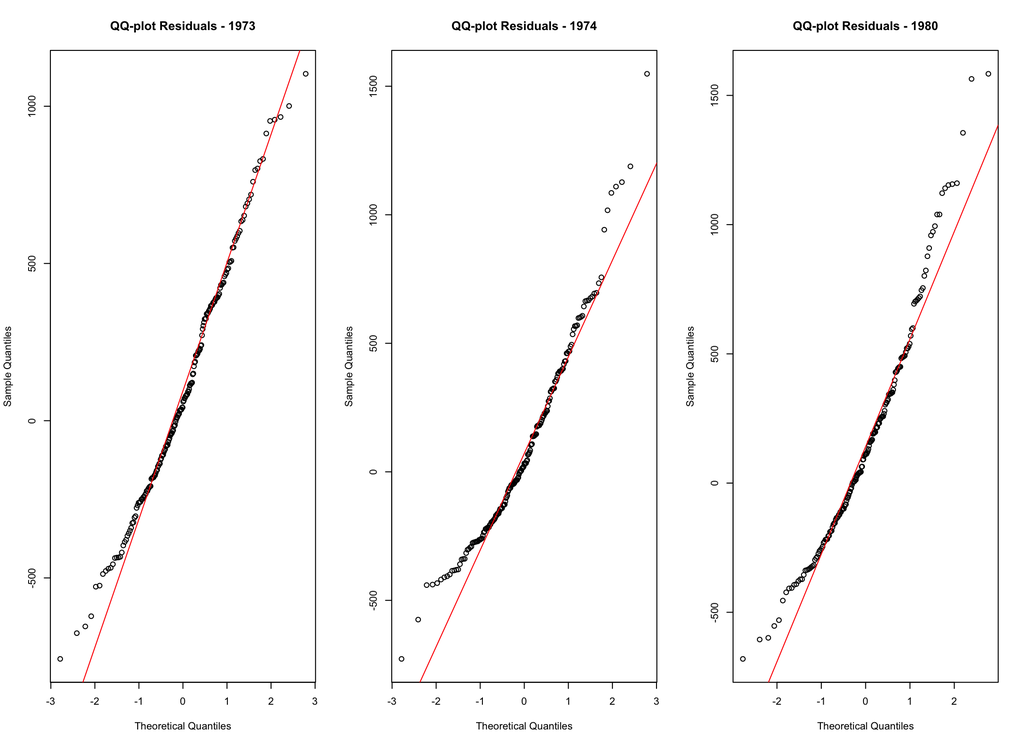

```r
# QQ-plots of residuals by year (original scale)
par(mfrow = c(1, 3))
for (yr in years) {
  y <- yrs[[yr]]
  tr <- trend_of(yr)
  f <- fit_of(yr)
  X <- model.matrix(tr, y$data)
  nu_val <- f$tau2 / f$sigma2
  g_res <- gls_ml(f$phi, nu_val, y$z, X, y$D, f$model, f$kappa)
  res <- y$z - X %*% g_res$beta
  qqnorm(res, main = paste("QQ-plot Residuals -", yr))
  qqline(res, col = "red")
}
```

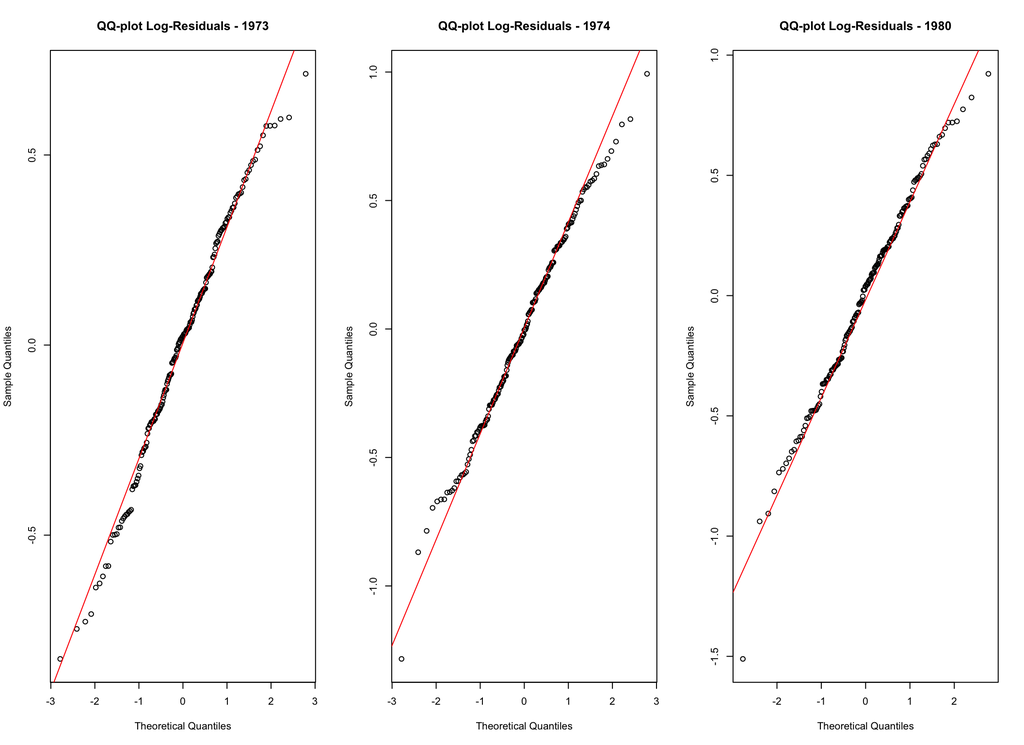

```r
par(mfrow = c(1, 1))

# QQ-plots of residuals by year (log-transformed scale)
par(mfrow = c(1, 3))
for (yr in years) {
  y <- yrs[[yr]]
  tr <- trend_of(yr)
  X <- model.matrix(tr, y$data)

  # Logarithmic transformation and linear model fit
  z_log <- log(y$z)
  lm_log <- lm(z_log ~ X - 1)
  res_log <- residuals(lm_log)

  qqnorm(res_log, main = paste("QQ-plot Log-Residuals -", yr))
  qqline(res_log, col = "red")
}
```

```r
par(mfrow = c(1, 1))
```

## 1.7 The final model: a Gaussian model on the log scale

The diagnostic of Section 1.6 shows that the Gaussian assumption is much better satisfied on $\log(z)$ than on $z$. The final model is therefore the model of the course applied to the logarithm of the rainfall:

$$\log Z_t(s) = X(s)\beta_t + W_t(s) + \varepsilon_t(s),$$

which means that the rainfall $Z_t(s)$ itself is log-normal: it is always positive, it is right-skewed, and the effects are multiplicative (the trend, the spatial process and the nugget act on the rainfall as factors, not as additions). For each year we keep the trend and the covariance model selected in Section 1.5 and we re-estimate all the parameters by ML on the log scale, with the same optimiser and the same starting values. As a consequence, $\sigma^2$ and $\tau^2$ are now variances of the log-rainfall (they have no unit), while $\phi$ is still in km.

```r
# Same trend and covariance model as selected in 1.5, parameters re-estimated on log(z)
fit_log <- lapply(setNames(years, years), function(yr) {
  y <- yrs[[yr]]
  b <- best_models[best_models$year == yr, ]
  j <- which(covs$label == b$covariance)
  fit_ml(log(y$z), model.matrix(trend_of(yr), y$data), y$D, covs$model[j], covs$kappa[j])
})

par_year <- data.frame(year   = years,
                       n      = sapply(yrs, function(y) length(y$z)),
                       trend  = best_models$trend,
                       cov    = best_models$covariance,
                       sigma2 = sapply(years, function(yr) fit_log[[yr]]$sigma2),
                       phi    = sapply(years, function(yr) fit_log[[yr]]$phi),
                       tau2   = sapply(years, function(yr) fit_log[[yr]]$tau2))
par_year$`nugget share (%)` <- 100 * par_year$tau2 / (par_year$tau2 + par_year$sigma2)

knitr::kable(par_year, digits = c(0, 0, 0, 0, 3, 1, 3, 1), row.names = FALSE,
             caption = "ML estimates on the log scale in each year (sigma2 and tau2 without unit, phi in km)")
```

ML estimates on the log scale in each year (sigma2 and tau2 without unit, phi in km)

| year | n | trend | cov | sigma2 | phi | tau2 | nugget share (%) |
| --- | --- | --- | --- | --- | --- | --- | --- |
| 1973 | 188 | linear_altitude | Spherical | 0.144 | 104.8 | 0.025 | 14.6 |
| 1974 | 187 | altitude | Spherical | 0.109 | 87.6 | 0.036 | 25.0 |
| 1980 | 178 | altitude | Exponential | 0.154 | 79.8 | 0.063 | 29.1 |

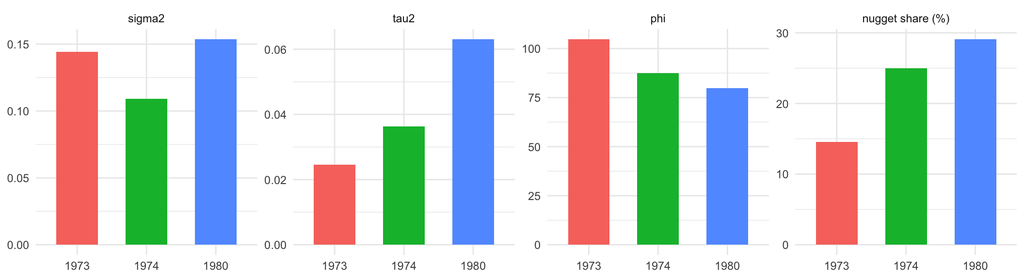

```r
params <- c("sigma2", "tau2", "phi", "nugget share (%)")
par_long <- do.call(rbind, lapply(params, function(v)
  data.frame(year = par_year$year, parameter = v, value = par_year[[v]])))
par_long$parameter <- factor(par_long$parameter, levels = params)

# Years are categories (no time axis), one panel per parameter with its own scale
ggplot(par_long, aes(year, value, fill = year)) +
  geom_col(width = 0.6, show.legend = FALSE) +
  facet_wrap(~ parameter, nrow = 1, scales = "free_y") +
  labs(x = NULL, y = NULL) + theme_minimal()
```

*Estimates of the final model (log scale) in each year. The nugget share is* $\tau^2 / (\tau^2 + \sigma^2)$.

The estimates describe the spatial structure of the log-rainfall in each year. The partial sill $\sigma^2$ is the largest in 1980 (0.154) and the range $\phi$ is the largest in 1973 (104.8 km). The nugget share goes from 14.6 % in 1973 to 29.1 % in 1980. On the log scale, the square root of a variance is approximately a relative variability of the rainfall (0.3 means about 30 %), which makes the three years easy to describe without reference to their average rainfall.

**Back-transformation.** At each point, the kriging gives a prediction $m$ and a variance $v$ (new observation) of the log-rainfall. The predictive distribution of the rainfall is then log-normal and we use:

- its median $e^{m}$, which is the prediction drawn on the maps;
- its mean $e^{m + v/2}$, which is the predictor that minimises the squared error (used for the RMSE);
- the 95 % prediction interval $\left[e^{m - 1.96\sqrt{v}},\ e^{m + 1.96\sqrt{v}}\right]$, obtained by transforming the bounds of the log scale, so it keeps its 95 % level. It is asymmetric (the upper bound is further from the median than the lower bound) and always positive.

# Part 2: kriging on the grid, year by year

The 1005 points of grid are not on a regular lattice, so the predictions are drawn as points. For each year, the specific trend of the optimal model selected for that year is evaluated at the grid points using the coordinates (and the altitude, if the trend uses it) provided in grid. The kriging parameters are the ML estimates of the log-scale model of each year (previous section): the kriging is done on $\log(z)$ and the results are back-transformed to mm.

```r
maps <- do.call(rbind, lapply(years, function(yr) {
  y <- yrs[[yr]]
  tr <- trend_of(yr)
  k <- krige_grid(log(y$z), model.matrix(tr, y$data), y$co,
                  fit_log[[yr]], grid, tr)       # pred, var_latent, var_obs: log scale
  data.frame(year = yr, XUTM = grid$XUTM, YUTM = grid$YUTM, k)
}))

# Back-transformation to mm (log-normal predictive distribution of a new observation)
m <- maps$pred;  v <- maps$var_obs
maps$pred  <- exp(m)                              # median
maps$mean  <- exp(m + v / 2)                      # mean
maps$sd    <- sqrt(exp(v) - 1) * maps$mean        # standard deviation (mm)
maps$lower <- exp(m - 1.96 * sqrt(v))             # 95 % prediction interval
maps$upper <- exp(m + 1.96 * sqrt(v))

map_summary <- aggregate(cbind(pred, sd) ~ year, data = maps, FUN = mean)
knitr::kable(map_summary, digits = 1,
             col.names = c("Year", "Mean predicted median (mm)", "Mean std. dev. (mm)"),
             caption = "Average over the grid points")
```

Average over the grid points

| Year | Mean predicted median (mm) | Mean std. dev. (mm) |
| --- | --- | --- |
| 1973 | 1159.2 | 262.5 |
| 1974 | 939.7 | 241.7 |
| 1980 | 1046.1 | 338.1 |

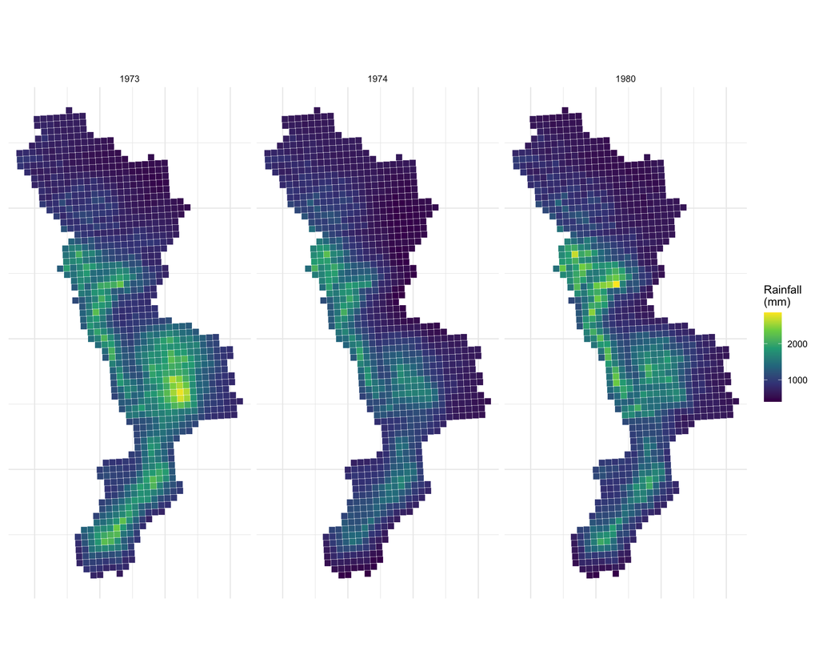

```r
map_theme <- theme_minimal() + theme(axis.text = element_blank(), axis.title = element_blank())

ggplot(maps, aes(XUTM, YUTM, colour = pred)) + geom_point(size = 2.5, , shape = 15) +
  facet_wrap(~ year) + coord_equal() +
  scale_colour_viridis_c(name = "Rainfall\n(mm)") + map_theme
```

*Predicted annual rainfall (median of the log-normal predictive distribution). All the years share the same colour scale, so they can be compared directly.*

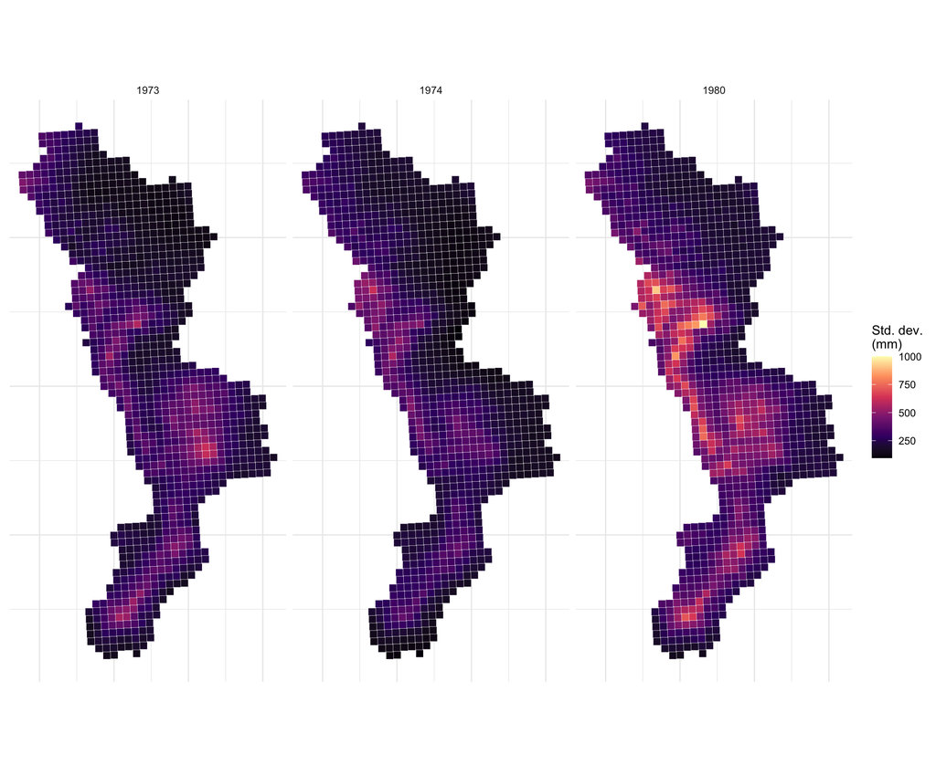

```r
ggplot(maps, aes(XUTM, YUTM, colour = sd)) + geom_point(size = 2.5, shape = 15) +
  facet_wrap(~ year) + coord_equal() +
  scale_colour_viridis_c(name = "Std. dev.\n(mm)", option = "magma") + map_theme
```

*Standard deviation (in mm) of the predictive distribution of a new observation. The data frame `maps` also contains `lower` and `upper`, the bounds of the 95 % prediction intervals, if they have to be mapped.*

The universal kriging maps show the spatial distribution of the annual rainfall in each year. Averaged over the grid, the wettest year is 1973 (1159.2 mm) and the driest is 1974 (939.7 mm).

With the log-normal model, the standard deviation in mm is not constant: it is proportional to the level of the rainfall, so the map of the standard deviation partly follows the map of the predictions (the wetter areas are also the more uncertain in mm). The relative uncertainty is driven by the variance $v$ on the log scale, which, as for any kriging, is larger far from the stations. The year with the largest average standard deviation is 1980 (338.1 mm); this can be compared with the parameters of the previous section.

## Calibration of the final model

If the predictive variance is correct, the standardised errors $(\log z_i - \hat m_i)/\sqrt{v_i}$ of the leave-one-out have a standard deviation close to 1 and 95 % of them are within $\pm 1.96$. The errors are computed on the log scale; since the log is increasing, the coverage is exactly the coverage of the interval in mm. The variance of a new observation is the one consistent with the target (an observed value, which contains the nugget); the coverage with the variance of the latent process is given for comparison. The RMSE is in mm, with the back-transformed mean $e^{m + v/2}$ as predictor, and is compared with the prediction by the mean of the other stations. The last two columns give the CRPS (in mm) of the predictive distribution of the rainfall for the log-normal model and for the Gaussian model on the original scale selected in Section 1.5, so they are on the same scale and comparable (both are leave-one-out scores with plug-in parameters).

```r
calib <- do.call(rbind, lapply(years, function(yr) {
  y  <- yrs[[yr]]; n <- length(y$z)
  zl <- log(y$z)
  cv <- loo(zl, model.matrix(trend_of(yr), y$data), y$D, fit_log[[yr]])
  e  <- zl - cv$pred                                   # log scale
  s  <- sqrt(cv$var_obs)
  pred_mm <- exp(cv$pred + cv$var_obs / 2)             # back-transformed mean
  data.frame(Year = yr, Stations = n,
             RMSE        = sqrt(mean((y$z - pred_mm)^2)),
             RMSE_others = sqrt(mean((y$z - (sum(y$z) - y$z) / (n - 1))^2)),
             SD_err      = sd(e / s),
             Cov_obs     = 100 * mean(abs(e / s) < 1.96),
             Cov_latent  = 100 * mean(abs(e / sqrt(cv$var_latent)) < 1.96),
             CRPS_lognormal = mean(crps_lnorm(y$z, cv$pred, s)),
             CRPS_gaussian  = best_models$CRPS[best_models$year == yr])
}))
knitr::kable(calib, digits = 2, row.names = FALSE,
             col.names = c("Year", "Stations", "RMSE (mm)", "RMSE mean of others (mm)",
                           "SD std. error", "Coverage 95 % (new obs.)", "Coverage 95 % (latent)",
                           "CRPS log-normal (mm)", "CRPS Gaussian (mm)"))
```

| Year | Stations | RMSE (mm) | RMSE mean of others (mm) | SD std. error | Coverage 95 % (new obs.) | Coverage 95 % (latent) | CRPS log-normal (mm) | CRPS Gaussian (mm) |
| --- | --- | --- | --- | --- | --- | --- | --- | --- |
| 1973 | 188 | 268.39 | 465.44 | 1.00 | 95.74 | 83.51 | 145.86 | 149.26 |
| 1974 | 187 | 233.99 | 408.25 | 0.99 | 94.65 | 82.35 | 122.49 | 127.39 |
| 1980 | 178 | 328.06 | 486.15 | 0.99 | 94.94 | 78.65 | 167.12 | 170.72 |

The RMSE of the kriging ranges from 234 to 328.1 mm, whereas the prediction by the mean of the other stations gives 408.2 to 486.1 mm: kriging is better than this naive prediction in the three years. The standard deviation of the standardised errors lies between 0.99 and 1 (the ideal value is 1), and the empirical coverage of the 95 % interval for a new observation between 94.7 % and 95.7 %, against 78.7 % to 83.5 % with the variance of the latent process only, which shows why the nugget has to be included in the intervals. Finally, the log-normal model has a lower (better) CRPS than the Gaussian model on the original scale in each year.

Overall, this work validates the methodological requirement to calibrate and select models independently for each year: the precipitation field changes too much from one year to the next for a single global model to be relevant. Universal kriging, supported by proper scoring rules (CRPS, LogS), isolated altitude as the main deterministic driver of precipitation in this domain, while mapping the uncertainty inherent in under-sampled geographical areas. The log transformation makes the Gaussian assumption reasonable, guarantees positive predictions and gives asymmetric prediction intervals.

However, these results must be interpreted in light of several limitations inherent in classical geostatistics. The approach relies on a strict assumption of spatial stationarity, assuming that the variance and correlation structure (the range) are constant across the entire territory, which is often an oversimplification in regions with complex topography where microclimates exist. Furthermore, the use of maximum likelihood relies on a “plug-in” method: the estimated parameters are considered perfectly known during kriging, which ignores the uncertainty associated with their own estimation. Finally, the trend and the covariance model were selected on the original scale and only the parameters were re-estimated on the log scale; repeating the selection of Section 1.5 on $\log(z)$ could change the chosen models.